# Spaceship Titanic Data Explanation

- **train.csv** - Personal records for about two-thirds (~8700) of the passengers, to be used as training data.
- **PassengerId** - A unique Id for each passenger. Each Id takes the form gggg_pp where gggg indicates a group the passenger is travelling with and pp is their number within the group. People in a group are often family members, but not always.
- **HomePlanet** - The planet the passenger departed from, typically their planet of permanent residence.
- **CryoSleep** - Indicates whether the passenger elected to be put into suspended animation for the duration of the voyage. Passengers in cryosleep are confined to their cabins.
- **Cabin** - The cabin number where the passenger is staying. Takes the form deck/num/side, where side can be either P for Port or S for Starboard.
- **Destination** - The planet the passenger will be debarking to.
- **Age** - The age of the passenger.
- **VIP** - Whether the passenger has paid for special VIP service during the voyage.
- **RoomService, FoodCourt, ShoppingMall, Spa, VRDeck** - Amount the passenger has billed at each of the Spaceship Titanic's many luxury amenities.
- **Name** - The first and last names of the passenger.
- **Transported** - Whether the passenger was transported to another dimension. This is the target, the column you are trying to predict.
- **test.csv** - Personal records for the remaining one-third (~4300) of the passengers, to be used as test data. Your task is to predict the value of
- **Transported** for the passengers in this set.
- **sample_submission.csv** - A submission file in the correct format.
- **PassengerId** - Id for each passenger in the test set.
- **Transported** - The target. For each passenger, predict either True or False.

```python
# import required packages
import matplotlib.pyplot as plt
import numpy as np
import pandas as pd
import seaborn as sns

# set matplotlib inline and use seaborn
%matplotlib inline
plt.style.use('seaborn')
```

```python
df = pd.read_csv('../data/train.csv')
df.info()
```

```
<class 'pandas.core.frame.DataFrame'>
RangeIndex: 8693 entries, 0 to 8692
Data columns (total 14 columns):
 #   Column        Non-Null Count  Dtype
---  ------        --------------  -----
 0   PassengerId   8693 non-null   object
 1   HomePlanet    8492 non-null   object
 2   CryoSleep     8476 non-null   object
 3   Cabin         8494 non-null   object
 4   Destination   8511 non-null   object
 5   Age           8514 non-null   float64
 6   VIP           8490 non-null   object
 7   RoomService   8512 non-null   float64
 8   FoodCourt     8510 non-null   float64
 9   ShoppingMall  8485 non-null   float64
 10  Spa           8510 non-null   float64
 11  VRDeck        8505 non-null   float64
 12  Name          8493 non-null   object
 13  Transported   8693 non-null   bool
dtypes: bool(1), float64(6), object(7)
memory usage: 891.5+ KB
```

```python
df.head(5)
```

|  | PassengerId | HomePlanet | CryoSleep | Cabin | Destination | Age | VIP | RoomService | FoodCourt | ShoppingMall | Spa | VRDeck | Name | Transported |
| --- | --- | --- | --- | --- | --- | --- | --- | --- | --- | --- | --- | --- | --- | --- |
| 0 | 0001_01 | Europa | False | B/0/P | TRAPPIST-1e | 39.0 | False | 0.0 | 0.0 | 0.0 | 0.0 | 0.0 | Maham Ofracculy | False |
| 1 | 0002_01 | Earth | False | F/0/S | TRAPPIST-1e | 24.0 | False | 109.0 | 9.0 | 25.0 | 549.0 | 44.0 | Juanna Vines | True |
| 2 | 0003_01 | Europa | False | A/0/S | TRAPPIST-1e | 58.0 | True | 43.0 | 3576.0 | 0.0 | 6715.0 | 49.0 | Altark Susent | False |
| 3 | 0003_02 | Europa | False | A/0/S | TRAPPIST-1e | 33.0 | False | 0.0 | 1283.0 | 371.0 | 3329.0 | 193.0 | Solam Susent | False |
| 4 | 0004_01 | Earth | False | F/1/S | TRAPPIST-1e | 16.0 | False | 303.0 | 70.0 | 151.0 | 565.0 | 2.0 | Willy Santantines | True |

```python
cabin_split = df.Cabin.str.split('/', expand=True)

cabin_split.columns = ['Deck','Num','Side']

df = pd.concat([df,cabin_split], axis=1).drop(columns=['Cabin'])

df.head()
```

|  | PassengerId | HomePlanet | CryoSleep | Destination | Age | VIP | RoomService | FoodCourt | ShoppingMall | Spa | VRDeck | Name | Transported | Deck | Num | Side |
| --- | --- | --- | --- | --- | --- | --- | --- | --- | --- | --- | --- | --- | --- | --- | --- | --- |
| 0 | 0001_01 | Europa | False | TRAPPIST-1e | 39.0 | False | 0.0 | 0.0 | 0.0 | 0.0 | 0.0 | Maham Ofracculy | False | B | 0 | P |
| 1 | 0002_01 | Earth | False | TRAPPIST-1e | 24.0 | False | 109.0 | 9.0 | 25.0 | 549.0 | 44.0 | Juanna Vines | True | F | 0 | S |
| 2 | 0003_01 | Europa | False | TRAPPIST-1e | 58.0 | True | 43.0 | 3576.0 | 0.0 | 6715.0 | 49.0 | Altark Susent | False | A | 0 | S |
| 3 | 0003_02 | Europa | False | TRAPPIST-1e | 33.0 | False | 0.0 | 1283.0 | 371.0 | 3329.0 | 193.0 | Solam Susent | False | A | 0 | S |
| 4 | 0004_01 | Earth | False | TRAPPIST-1e | 16.0 | False | 303.0 | 70.0 | 151.0 | 565.0 | 2.0 | Willy Santantines | True | F | 1 | S |

```python
df.info()
```

```
<class 'pandas.core.frame.DataFrame'>
RangeIndex: 8693 entries, 0 to 8692
Data columns (total 16 columns):
 #   Column        Non-Null Count  Dtype
---  ------        --------------  -----
 0   PassengerId   8693 non-null   object
 1   HomePlanet    8492 non-null   object
 2   CryoSleep     8476 non-null   object
 3   Destination   8511 non-null   object
 4   Age           8514 non-null   float64
 5   VIP           8490 non-null   object
 6   RoomService   8512 non-null   float64
 7   FoodCourt     8510 non-null   float64
 8   ShoppingMall  8485 non-null   float64
 9   Spa           8510 non-null   float64
 10  VRDeck        8505 non-null   float64
 11  Name          8493 non-null   object
 12  Transported   8693 non-null   bool
 13  Deck          8494 non-null   object
 14  Num           8494 non-null   object
 15  Side          8494 non-null   object
dtypes: bool(1), float64(6), object(9)
memory usage: 1.0+ MB
```

```python
df.isnull().sum()
```

```
PassengerId       0
HomePlanet      201
CryoSleep       217
Destination     182
Age             179
VIP             203
RoomService     181
FoodCourt       183
ShoppingMall    208
Spa             183
VRDeck          188
Name            200
Transported       0
Deck            199
Num             199
Side            199
dtype: int64
```

```python
df['Num']=df['Num'].astype(float).astype('Int32')
```

```python
from sklearn.impute import SimpleImputer
median_imputer = SimpleImputer(strategy='median')

df_num = df.select_dtypes(include=['Int32','int64','float64','bool'])

df_num_fill_median = median_imputer.fit_transform(df_num)

df_num_fill_median = pd.DataFrame(df_num_fill_median, columns=df_num.columns)
df_num_fill_median.isnull().sum()
```

```
Age             0
RoomService     0
FoodCourt       0
ShoppingMall    0
Spa             0
VRDeck          0
Transported     0
Num             0
dtype: int64
```

```python
df.describe(include='all')
```

|  | PassengerId | HomePlanet | CryoSleep | Destination | Age | VIP | RoomService | FoodCourt | ShoppingMall | Spa | VRDeck | Name | Transported | Deck | Num | Side |
| --- | --- | --- | --- | --- | --- | --- | --- | --- | --- | --- | --- | --- | --- | --- | --- | --- |
| count | 8693 | 8492 | 8476 | 8511 | 8514.000000 | 8490 | 8512.000000 | 8510.000000 | 8485.000000 | 8510.000000 | 8505.000000 | 8493 | 8693 | 8494 | 8494.000000 | 8494 |
| unique | 8693 | 3 | 2 | 3 | NaN | 2 | NaN | NaN | NaN | NaN | NaN | 8473 | 2 | 8 | NaN | 2 |
| top | 0001_01 | Earth | False | TRAPPIST-1e | NaN | False | NaN | NaN | NaN | NaN | NaN | Gollux Reedall | True | F | NaN | S |
| freq | 1 | 4602 | 5439 | 5915 | NaN | 8291 | NaN | NaN | NaN | NaN | NaN | 2 | 4378 | 2794 | NaN | 4288 |
| mean | NaN | NaN | NaN | NaN | 28.827930 | NaN | 224.687617 | 458.077203 | 173.729169 | 311.138778 | 304.854791 | NaN | NaN | NaN | 600.367671 | NaN |
| std | NaN | NaN | NaN | NaN | 14.489021 | NaN | 666.717663 | 1611.489240 | 604.696458 | 1136.705535 | 1145.717189 | NaN | NaN | NaN | 511.867226 | NaN |
| min | NaN | NaN | NaN | NaN | 0.000000 | NaN | 0.000000 | 0.000000 | 0.000000 | 0.000000 | 0.000000 | NaN | NaN | NaN | 0.000000 | NaN |
| 25% | NaN | NaN | NaN | NaN | 19.000000 | NaN | 0.000000 | 0.000000 | 0.000000 | 0.000000 | 0.000000 | NaN | NaN | NaN | 167.250000 | NaN |
| 50% | NaN | NaN | NaN | NaN | 27.000000 | NaN | 0.000000 | 0.000000 | 0.000000 | 0.000000 | 0.000000 | NaN | NaN | NaN | 427.000000 | NaN |
| 75% | NaN | NaN | NaN | NaN | 38.000000 | NaN | 47.000000 | 76.000000 | 27.000000 | 59.000000 | 46.000000 | NaN | NaN | NaN | 999.000000 | NaN |
| max | NaN | NaN | NaN | NaN | 79.000000 | NaN | 14327.000000 | 29813.000000 | 23492.000000 | 22408.000000 | 24133.000000 | NaN | NaN | NaN | 1894.000000 | NaN |

```python
df.drop(['PassengerId','Name'], axis = 1, inplace = True)
```

```python
df.info()
```

```
<class 'pandas.core.frame.DataFrame'>
RangeIndex: 8693 entries, 0 to 8692
Data columns (total 14 columns):
 #   Column        Non-Null Count  Dtype
---  ------        --------------  -----
 0   HomePlanet    8492 non-null   object
 1   CryoSleep     8476 non-null   object
 2   Destination   8511 non-null   object
 3   Age           8514 non-null   float64
 4   VIP           8490 non-null   object
 5   RoomService   8512 non-null   float64
 6   FoodCourt     8510 non-null   float64
 7   ShoppingMall  8485 non-null   float64
 8   Spa           8510 non-null   float64
 9   VRDeck        8505 non-null   float64
 10  Transported   8693 non-null   bool
 11  Deck          8494 non-null   object
 12  Num           8494 non-null   Int32
 13  Side          8494 non-null   object
dtypes: Int32(1), bool(1), float64(6), object(6)
memory usage: 866.0+ KB
```

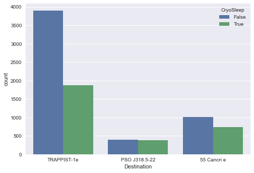

```python
sns.countplot(data=df, x='Destination', hue='CryoSleep')
```

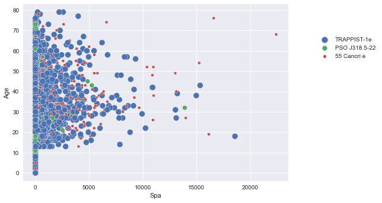

```python
g = sns.scatterplot(data=df, x='Spa', y='Age', hue='Destination', size='Destination')
g.legend(loc='right', bbox_to_anchor=(1.35, 0.75), ncol=1)
```

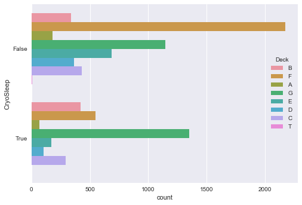

```python
sns.countplot(data=df, y='CryoSleep', hue='Deck')
plt.show()
```

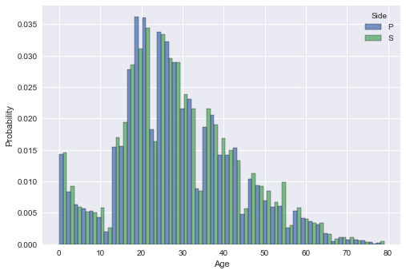

```python
sns.histplot(data=df, x='Age', hue='Side', stat='probability', multiple='dodge')
```

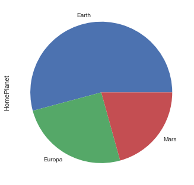

```python
df.HomePlanet.value_counts().plot(kind='pie')
```

```python
df_cat = df.select_dtypes(['object'])
df_cat.head()
```

|  | HomePlanet | CryoSleep | Destination | VIP | Deck | Side |
| --- | --- | --- | --- | --- | --- | --- |
| 0 | Europa | False | TRAPPIST-1e | False | B | P |
| 1 | Earth | False | TRAPPIST-1e | False | F | S |
| 2 | Europa | False | TRAPPIST-1e | True | A | S |
| 3 | Europa | False | TRAPPIST-1e | False | A | S |
| 4 | Earth | False | TRAPPIST-1e | False | F | S |

```python
df_cat.describe()
```

|  | HomePlanet | CryoSleep | Destination | VIP | Deck | Side |
| --- | --- | --- | --- | --- | --- | --- |
| count | 8492 | 8476 | 8511 | 8490 | 8494 | 8494 |
| unique | 3 | 2 | 3 | 2 | 8 | 2 |
| top | Earth | False | TRAPPIST-1e | False | F | S |
| freq | 4602 | 5439 | 5915 | 8291 | 2794 | 4288 |

```python
y = df_num_fill_median['Transported']
df_num_fill_median.drop(['Transported'], axis=1, inplace=True)
```

```python
from sklearn.impute import SimpleImputer

imp = SimpleImputer(strategy="most_frequent")

df_cat = imp.fit_transform(df_cat)

from sklearn.preprocessing import OneHotEncoder

onehot_encoder = OneHotEncoder()
df_cat_onehot_encoded = onehot_encoder.fit_transform(df_cat)

onehot_encoder.categories_
```

```
[array(['Earth', 'Europa', 'Mars'], dtype=object),
 array([False, True], dtype=object),
 array(['55 Cancri e', 'PSO J318.5-22', 'TRAPPIST-1e'], dtype=object),
 array([False, True], dtype=object),
 array(['A', 'B', 'C', 'D', 'E', 'F', 'G', 'T'], dtype=object),
 array(['P', 'S'], dtype=object)]
```

```python
column_names = onehot_encoder.get_feature_names()
column_names
```

```
array(['x0_Earth', 'x0_Europa', 'x0_Mars', 'x1_False', 'x1_True',
       'x2_55 Cancri e', 'x2_PSO J318.5-22', 'x2_TRAPPIST-1e', 'x3_False',
       'x3_True', 'x4_A', 'x4_B', 'x4_C', 'x4_D', 'x4_E', 'x4_F', 'x4_G',
       'x4_T', 'x5_P', 'x5_S'], dtype=object)
```

```python
df_cat_onehot_encoded = df_cat_onehot_encoded.toarray()
df_cat_onehot_encoded = pd.DataFrame(df_cat_onehot_encoded, columns=column_names)
df_cat_onehot_encoded.head()
```

|  | x0_Earth | x0_Europa | x0_Mars | x1_False | x1_True | x2_55 Cancri e | x2_PSO J318.5-22 | x2_TRAPPIST-1e | x3_False | x3_True | x4_A | x4_B | x4_C | x4_D | x4_E | x4_F | x4_G | x4_T | x5_P | x5_S |
| --- | --- | --- | --- | --- | --- | --- | --- | --- | --- | --- | --- | --- | --- | --- | --- | --- | --- | --- | --- | --- |
| 0 | 0.0 | 1.0 | 0.0 | 1.0 | 0.0 | 0.0 | 0.0 | 1.0 | 1.0 | 0.0 | 0.0 | 1.0 | 0.0 | 0.0 | 0.0 | 0.0 | 0.0 | 0.0 | 1.0 | 0.0 |
| 1 | 1.0 | 0.0 | 0.0 | 1.0 | 0.0 | 0.0 | 0.0 | 1.0 | 1.0 | 0.0 | 0.0 | 0.0 | 0.0 | 0.0 | 0.0 | 1.0 | 0.0 | 0.0 | 0.0 | 1.0 |
| 2 | 0.0 | 1.0 | 0.0 | 1.0 | 0.0 | 0.0 | 0.0 | 1.0 | 0.0 | 1.0 | 1.0 | 0.0 | 0.0 | 0.0 | 0.0 | 0.0 | 0.0 | 0.0 | 0.0 | 1.0 |
| 3 | 0.0 | 1.0 | 0.0 | 1.0 | 0.0 | 0.0 | 0.0 | 1.0 | 1.0 | 0.0 | 1.0 | 0.0 | 0.0 | 0.0 | 0.0 | 0.0 | 0.0 | 0.0 | 0.0 | 1.0 |
| 4 | 1.0 | 0.0 | 0.0 | 1.0 | 0.0 | 0.0 | 0.0 | 1.0 | 1.0 | 0.0 | 0.0 | 0.0 | 0.0 | 0.0 | 0.0 | 1.0 | 0.0 | 0.0 | 0.0 | 1.0 |

```python
titanic_train_onehot_encoded = pd.concat([df_num_fill_median, df_cat_onehot_encoded], axis=1)
titanic_train_onehot_encoded.columns=['Age','RoomService','FoodCourt',
                                     'ShoppingMall','Spa','VRDeck','CabNum',
                                     'HP-Earth','HP-Europa','HP-Mars',
                                     'NoCryoSleep','CryoSleep',
                                     'D-55 Cancri e', 'D-PSO J318.5-22',
                                     'D-TRAPPIST-1e','NotVIP','VIP',
                                     'Deck-A','Deck-B','Deck-C',
                                     'Deck-D','Deck-E','Deck-F',
                                     'Deck-G','Deck-T','Port','Starboard']
titanic_train_onehot_encoded.info()
```

```
<class 'pandas.core.frame.DataFrame'>
RangeIndex: 8693 entries, 0 to 8692
Data columns (total 27 columns):
 #   Column           Non-Null Count  Dtype
---  ------           --------------  -----
 0   Age              8693 non-null   float64
 1   RoomService      8693 non-null   float64
 2   FoodCourt        8693 non-null   float64
 3   ShoppingMall     8693 non-null   float64
 4   Spa              8693 non-null   float64
 5   VRDeck           8693 non-null   float64
 6   CabNum           8693 non-null   float64
 7   HP-Earth         8693 non-null   float64
 8   HP-Europa        8693 non-null   float64
 9   HP-Mars          8693 non-null   float64
```

[output cut: 19 more lines]

## OneHot Prediction Model

```python
df_test = pd.read_csv('../data/test.csv')
df_test.info()
```

```
<class 'pandas.core.frame.DataFrame'>
RangeIndex: 4277 entries, 0 to 4276
Data columns (total 13 columns):
 #   Column        Non-Null Count  Dtype
---  ------        --------------  -----
 0   PassengerId   4277 non-null   object
 1   HomePlanet    4190 non-null   object
 2   CryoSleep     4184 non-null   object
 3   Cabin         4177 non-null   object
 4   Destination   4185 non-null   object
 5   Age           4186 non-null   float64
 6   VIP           4184 non-null   object
 7   RoomService   4195 non-null   float64
 8   FoodCourt     4171 non-null   float64
 9   ShoppingMall  4179 non-null   float64
 10  Spa           4176 non-null   float64
 11  VRDeck        4197 non-null   float64
 12  Name          4183 non-null   object
dtypes: float64(6), object(7)
memory usage: 434.5+ KB
```

```python
cabin_split = df_test.Cabin.str.split('/', expand=True)

cabin_split.columns = ['Deck','Num','Side']

df_test = pd.concat([df_test,cabin_split], axis=1)
```

```python
df_test['Num']=df_test['Num'].astype(float).astype('Int32')
```

```python
df_test_id = df_test['PassengerId']

df_test.drop(['PassengerId','Name','Cabin'], axis = 1, inplace = True)

df_test.info()
```

```
<class 'pandas.core.frame.DataFrame'>
RangeIndex: 4277 entries, 0 to 4276
Data columns (total 13 columns):
 #   Column        Non-Null Count  Dtype
---  ------        --------------  -----
 0   HomePlanet    4190 non-null   object
 1   CryoSleep     4184 non-null   object
 2   Destination   4185 non-null   object
 3   Age           4186 non-null   float64
 4   VIP           4184 non-null   object
 5   RoomService   4195 non-null   float64
 6   FoodCourt     4171 non-null   float64
 7   ShoppingMall  4179 non-null   float64
 8   Spa           4176 non-null   float64
 9   VRDeck        4197 non-null   float64
 10  Deck          4177 non-null   object
 11  Num           4177 non-null   Int32
 12  Side          4177 non-null   object
dtypes: Int32(1), float64(6), object(6)
memory usage: 422.0+ KB
```

```python
df_test.isnull().sum()
```

```
HomePlanet       87
CryoSleep        93
Destination      92
Age              91
VIP              93
RoomService      82
FoodCourt       106
ShoppingMall     98
Spa             101
VRDeck           80
Deck            100
Num             100
Side            100
dtype: int64
```

```python
median_imputer = SimpleImputer(strategy='median')

df_test_num = df_test.select_dtypes(include=['Int32','int64','float64'])

df_test_num_fill_median = median_imputer.fit_transform(df_test_num)

df_test_num_fill_median = pd.DataFrame(df_test_num_fill_median, columns=df_test_num.columns)
df_test_num_fill_median.isnull().sum()
```

```
Age             0
RoomService     0
FoodCourt       0
ShoppingMall    0
Spa             0
VRDeck          0
Num             0
dtype: int64
```

```python
df_test_cat = df_test.select_dtypes(include=['object'])
df_test_cat.info()
```

```
<class 'pandas.core.frame.DataFrame'>
RangeIndex: 4277 entries, 0 to 4276
Data columns (total 6 columns):
 #   Column       Non-Null Count  Dtype
---  ------       --------------  -----
 0   HomePlanet   4190 non-null   object
 1   CryoSleep    4184 non-null   object
 2   Destination  4185 non-null   object
 3   VIP          4184 non-null   object
 4   Deck         4177 non-null   object
 5   Side         4177 non-null   object
dtypes: object(6)
memory usage: 200.6+ KB
```

```python
df_test_cat = imp.fit_transform(df_test_cat)

df_test_cat_onthot_encoded = onehot_encoder.fit_transform(df_test_cat)

column_names = onehot_encoder.get_feature_names()

df_test_cat_onthot_encoded = df_test_cat_onthot_encoded.toarray()

df_test_cat_onthot_encoded = pd.DataFrame(df_test_cat_onthot_encoded, columns=column_names)

df_test_cat_onthot_encoded.columns=['HP-Earth','HP-Europa','HP-Mars',
                                    'NoCryoSleep','CryoSleep','D-55 Cancri e', 'D-PSO J318.5-22',
                                    'D-TRAPPIST-1e','NotVIP','VIP','Deck-A','Deck-B','Deck-C',
                                    'Deck-D','Deck-E','Deck-F','Deck-G','Deck-T','Port','Starboard']

df_test_cat_onthot_encoded.columns
```

```
Index(['HP-Earth', 'HP-Europa', 'HP-Mars', 'NoCryoSleep', 'CryoSleep',
       'D-55 Cancri e', 'D-PSO J318.5-22', 'D-TRAPPIST-1e', 'NotVIP', 'VIP',
       'Deck-A', 'Deck-B', 'Deck-C', 'Deck-D', 'Deck-E', 'Deck-F', 'Deck-G',
       'Deck-T', 'Port', 'Starboard'],
      dtype='object')
```

```python
df_test_cat_onthot_encoded.info()
```

```
<class 'pandas.core.frame.DataFrame'>
RangeIndex: 4277 entries, 0 to 4276
Data columns (total 20 columns):
 #   Column           Non-Null Count  Dtype
---  ------           --------------  -----
 0   HP-Earth         4277 non-null   float64
 1   HP-Europa        4277 non-null   float64
 2   HP-Mars          4277 non-null   float64
 3   NoCryoSleep      4277 non-null   float64
 4   CryoSleep        4277 non-null   float64
 5   D-55 Cancri e    4277 non-null   float64
 6   D-PSO J318.5-22  4277 non-null   float64
 7   D-TRAPPIST-1e    4277 non-null   float64
 8   NotVIP           4277 non-null   float64
 9   VIP              4277 non-null   float64
 10  Deck-A           4277 non-null   float64
 11  Deck-B           4277 non-null   float64
 12  Deck-C           4277 non-null   float64
 13  Deck-D           4277 non-null   float64
 14  Deck-E           4277 non-null   float64
 15  Deck-F           4277 non-null   float64
 16  Deck-G           4277 non-null   float64
 17  Deck-T           4277 non-null   float64
 18  Port             4277 non-null   float64
 19  Starboard        4277 non-null   float64
dtypes: float64(20)
memory usage: 668.4 KB
```

```python
titanic_test_encoded = pd.concat([df_test_num_fill_median, df_test_cat_onthot_encoded], axis=1)

titanic_test_encoded.info()
```

```
<class 'pandas.core.frame.DataFrame'>
RangeIndex: 4277 entries, 0 to 4276
Data columns (total 27 columns):
 #   Column           Non-Null Count  Dtype
---  ------           --------------  -----
 0   Age              4277 non-null   float64
 1   RoomService      4277 non-null   float64
 2   FoodCourt        4277 non-null   float64
 3   ShoppingMall     4277 non-null   float64
 4   Spa              4277 non-null   float64
 5   VRDeck           4277 non-null   float64
 6   Num              4277 non-null   float64
 7   HP-Earth         4277 non-null   float64
 8   HP-Europa        4277 non-null   float64
 9   HP-Mars          4277 non-null   float64
```

[output cut: 19 more lines]

```python
titanic_test_encoded.isnull().sum()
```

```
Age                0
RoomService        0
FoodCourt          0
ShoppingMall       0
Spa                0
VRDeck             0
Num                0
HP-Earth           0
HP-Europa          0
HP-Mars            0
NoCryoSleep        0
CryoSleep          0
D-55 Cancri e      0
D-PSO J318.5-22    0
D-TRAPPIST-1e      0
NotVIP             0
VIP                0
Deck-A             0
Deck-B             0
Deck-C             0
Deck-D             0
Deck-E             0
Deck-F             0
Deck-G             0
Deck-T             0
Port               0
Starboard          0
dtype: int64
```

```python
titanic_test_encoded.columns.values
```

```
array(['Age', 'RoomService', 'FoodCourt', 'ShoppingMall', 'Spa', 'VRDeck',
       'Num', 'HP-Earth', 'HP-Europa', 'HP-Mars', 'NoCryoSleep',
       'CryoSleep', 'D-55 Cancri e', 'D-PSO J318.5-22', 'D-TRAPPIST-1e',
       'NotVIP', 'VIP', 'Deck-A', 'Deck-B', 'Deck-C', 'Deck-D', 'Deck-E',
       'Deck-F', 'Deck-G', 'Deck-T', 'Port', 'Starboard'], dtype=object)
```

```python
titanic_train_onehot_encoded.columns.values
```

```
array(['Age', 'RoomService', 'FoodCourt', 'ShoppingMall', 'Spa', 'VRDeck',
       'CabNum', 'HP-Earth', 'HP-Europa', 'HP-Mars', 'NoCryoSleep',
       'CryoSleep', 'D-55 Cancri e', 'D-PSO J318.5-22', 'D-TRAPPIST-1e',
       'NotVIP', 'VIP', 'Deck-A', 'Deck-B', 'Deck-C', 'Deck-D', 'Deck-E',
       'Deck-F', 'Deck-G', 'Deck-T', 'Port', 'Starboard'], dtype=object)
```

```python
titanic_test_encoded.head()
```

|  | Age | RoomService | FoodCourt | ShoppingMall | Spa | VRDeck | Num | HP-Earth | HP-Europa | HP-Mars | ... | Deck-A | Deck-B | Deck-C | Deck-D | Deck-E | Deck-F | Deck-G | Deck-T | Port | Starboard |
| --- | --- | --- | --- | --- | --- | --- | --- | --- | --- | --- | --- | --- | --- | --- | --- | --- | --- | --- | --- | --- | --- |
| 0 | 27.0 | 0.0 | 0.0 | 0.0 | 0.0 | 0.0 | 3.0 | 1.0 | 0.0 | 0.0 | ... | 0.0 | 0.0 | 0.0 | 0.0 | 0.0 | 0.0 | 1.0 | 0.0 | 0.0 | 1.0 |
| 1 | 19.0 | 0.0 | 9.0 | 0.0 | 2823.0 | 0.0 | 4.0 | 1.0 | 0.0 | 0.0 | ... | 0.0 | 0.0 | 0.0 | 0.0 | 0.0 | 1.0 | 0.0 | 0.0 | 0.0 | 1.0 |
| 2 | 31.0 | 0.0 | 0.0 | 0.0 | 0.0 | 0.0 | 0.0 | 0.0 | 1.0 | 0.0 | ... | 0.0 | 0.0 | 1.0 | 0.0 | 0.0 | 0.0 | 0.0 | 0.0 | 0.0 | 1.0 |
| 3 | 38.0 | 0.0 | 6652.0 | 0.0 | 181.0 | 585.0 | 1.0 | 0.0 | 1.0 | 0.0 | ... | 0.0 | 0.0 | 1.0 | 0.0 | 0.0 | 0.0 | 0.0 | 0.0 | 0.0 | 1.0 |
| 4 | 20.0 | 10.0 | 0.0 | 635.0 | 0.0 | 0.0 | 5.0 | 1.0 | 0.0 | 0.0 | ... | 0.0 | 0.0 | 0.0 | 0.0 | 0.0 | 1.0 | 0.0 | 0.0 | 0.0 | 1.0 |

5 rows × 27 columns

```python
from sklearn.tree import DecisionTreeClassifier
tree_clf2 = DecisionTreeClassifier(criterion='entropy',
                                   max_depth=9,
                                   splitter='best',
                                   max_features='auto',
                                   )
tree_clf2.fit(titanic_train_onehot_encoded, y)

y_hat_onehot = tree_clf2.predict(titanic_test_encoded)
y_hat_onehot.shape
```

```
(4277,)
```

```python
y_hat_onehot
```

```
array([1., 0., 1., ..., 1., 1., 1.])
```

```python
y_hat_onehot.astype(int)
```

```
array([1, 0, 1, ..., 1, 1, 1])
```

```python
tree2_onehot = pd.DataFrame({
    'PassengerId': df_test_id,
    'Transported': y_hat_onehot.astype(bool),
})
```

```python
tree2_onehot.head()
```

|  | PassengerId | Transported |
| --- | --- | --- |
| 0 | 0013_01 | True |
| 1 | 0018_01 | False |
| 2 | 0019_01 | True |
| 3 | 0021_01 | True |
| 4 | 0023_01 | True |

```python
tree2_onehot.to_csv('../data/Group_Model_1.csv', index=False)
```

```python
titanic_test_encoded.head()
```

|  | Age | RoomService | FoodCourt | ShoppingMall | Spa | VRDeck | Num | HP-Earth | HP-Europa | HP-Mars | ... | Deck-A | Deck-B | Deck-C | Deck-D | Deck-E | Deck-F | Deck-G | Deck-T | Port | Starboard |
| --- | --- | --- | --- | --- | --- | --- | --- | --- | --- | --- | --- | --- | --- | --- | --- | --- | --- | --- | --- | --- | --- |
| 0 | 27.0 | 0.0 | 0.0 | 0.0 | 0.0 | 0.0 | 3.0 | 1.0 | 0.0 | 0.0 | ... | 0.0 | 0.0 | 0.0 | 0.0 | 0.0 | 0.0 | 1.0 | 0.0 | 0.0 | 1.0 |
| 1 | 19.0 | 0.0 | 9.0 | 0.0 | 2823.0 | 0.0 | 4.0 | 1.0 | 0.0 | 0.0 | ... | 0.0 | 0.0 | 0.0 | 0.0 | 0.0 | 1.0 | 0.0 | 0.0 | 0.0 | 1.0 |
| 2 | 31.0 | 0.0 | 0.0 | 0.0 | 0.0 | 0.0 | 0.0 | 0.0 | 1.0 | 0.0 | ... | 0.0 | 0.0 | 1.0 | 0.0 | 0.0 | 0.0 | 0.0 | 0.0 | 0.0 | 1.0 |
| 3 | 38.0 | 0.0 | 6652.0 | 0.0 | 181.0 | 585.0 | 1.0 | 0.0 | 1.0 | 0.0 | ... | 0.0 | 0.0 | 1.0 | 0.0 | 0.0 | 0.0 | 0.0 | 0.0 | 0.0 | 1.0 |
| 4 | 20.0 | 10.0 | 0.0 | 635.0 | 0.0 | 0.0 | 5.0 | 1.0 | 0.0 | 0.0 | ... | 0.0 | 0.0 | 0.0 | 0.0 | 0.0 | 1.0 | 0.0 | 0.0 | 0.0 | 1.0 |

5 rows × 27 columns

## A Naive Prediction Model

```python
df_test = pd.read_csv('../data/test.csv')
df_test['Transported'] = 0
df_test['CryoSleep_Transported'] = df_test['CryoSleep'].apply(lambda x: False if x==False else True)
df_test.head()
```

|  | PassengerId | HomePlanet | CryoSleep | Cabin | Destination | Age | VIP | RoomService | FoodCourt | ShoppingMall | Spa | VRDeck | Name | Transported | CryoSleep_Transported |
| --- | --- | --- | --- | --- | --- | --- | --- | --- | --- | --- | --- | --- | --- | --- | --- |
| 0 | 0013_01 | Earth | True | G/3/S | TRAPPIST-1e | 27.0 | False | 0.0 | 0.0 | 0.0 | 0.0 | 0.0 | Nelly Carsoning | 0 | True |
| 1 | 0018_01 | Earth | False | F/4/S | TRAPPIST-1e | 19.0 | False | 0.0 | 9.0 | 0.0 | 2823.0 | 0.0 | Lerome Peckers | 0 | False |
| 2 | 0019_01 | Europa | True | C/0/S | 55 Cancri e | 31.0 | False | 0.0 | 0.0 | 0.0 | 0.0 | 0.0 | Sabih Unhearfus | 0 | True |
| 3 | 0021_01 | Europa | False | C/1/S | TRAPPIST-1e | 38.0 | False | 0.0 | 6652.0 | 0.0 | 181.0 | 585.0 | Meratz Caltilter | 0 | False |
| 4 | 0023_01 | Earth | False | F/5/S | TRAPPIST-1e | 20.0 | False | 10.0 | 0.0 | 635.0 | 0.0 | 0.0 | Brence Harperez | 0 | False |

```python
df_Model_2 = df_test[['PassengerId','CryoSleep_Transported']]
df_Model_2.to_csv('../data/Group_Model_2.csv', index=False, header=['PassengerId', 'Transported'])
```

## Tree Model Gini

```python
#
from sklearn.tree import DecisionTreeClassifier
tree_clf2 = DecisionTreeClassifier(criterion='gini',
                                   max_depth=11,
                                   splitter='best',
                                   max_features='auto',
                                  )
tree_clf2.fit(titanic_train_onehot_encoded, y)
y_hat = tree_clf2.predict(titanic_test_encoded)
y_hat.astype(bool)
```

```
array([ True, False,  True, ...,  True, False, False])
```

```python
tree = pd.DataFrame({
    'PassengerId': df_test_id,
    'Transported': y_hat.astype(bool),
})
```

```python
tree.head()
```

|  | PassengerId | Transported |
| --- | --- | --- |
| 0 | 0013_01 | True |
| 1 | 0018_01 | False |
| 2 | 0019_01 | True |
| 3 | 0021_01 | True |
| 4 | 0023_01 | True |

```python
tree.to_csv('../data/Group_Model_3.csv', index=False)
```